# HW2_Curran(v2)

Thomas Curran

4/26/2017

Debating with Quanteda: 1) Install the quanteda package: 2) Create DEBATES Object

3. Explore to what extent the Heap’s Law applies for trump vs Clinton. Is it stronger or weaker for either candidate?

```r
debate_sum <- summary(DEBATES)
# clinton speaches
clinton <- corpus_subset(DEBATES, speaker == "clinton")
clinton_sum <- summary(clinton)

# before accepting democratic nomination
clinton_0 <- corpus_subset(DEBATES, speaker == "clinton" & primary == 0)
clinton_0_sum <- summary(clinton)

# after accepting democratic nomination
clinton_1 <- corpus_subset(DEBATES, speaker == "clinton" & primary == 1)
clinton_1_sum <- summary(clinton)

# trump speaches
trump <- corpus_subset(DEBATES, speaker == "trump")
trump_sum <- summary(trump)

# before accepting nomination:
trump_0 <- corpus_subset(DEBATES, speaker == "trump" & primary == 0)
trump_0_sum <- summary(trump_0)

# after accepting nomination

trump_1 <- corpus_subset(DEBATES, speaker == "trump" & primary == 1)
trump_1_sum <- summary(trump_1)
```

```r
#Trump Heap
pander(summary(lm(log(trump_sum$Types) ~log(trump_sum$Tokens))))
```

|  | Estimate | Std. Error | t value | Pr(>\|t\|) |
| --- | --- | --- | --- | --- |
| **log(trump_sum$Tokens)** | 0.8602 | 0.012 | 71.66 | 1.808e-86 |
| **(Intercept)** | 0.1655 | 0.03684 | 4.492 | 1.93e-05 |

Fitting linear model: log(trump_sum$Types) ~ log(trump_sum$Tokens)

| Observations | Residual Std. Error | $R^2$ | Adjusted $R^2$ |
| --- | --- | --- | --- |
| 100 | 0.1509 | 0.9813 | 0.9811 |

```r
#Clinton Heap
pander(summary(lm(log(clinton_sum$Types) ~log(clinton_sum$Tokens))))
```

|  | Estimate | Std. Error | t value | Pr(>\|t\|) |
| --- | --- | --- | --- | --- |
| **log(clinton_sum$Tokens)** | 0.9135 | 0.01375 | 66.42 | 2.656e-83 |
| **(Intercept)** | -0.05524 | 0.05401 | -1.023 | 0.3089 |

Fitting linear model: log(clinton_sum$Types) ~ log(clinton_sum$Tokens)

| Observations | Residual Std. Error | $R^2$ | Adjusted $R^2$ |
| --- | --- | --- | --- |
| 100 | 0.1856 | 0.9783 | 0.978 |

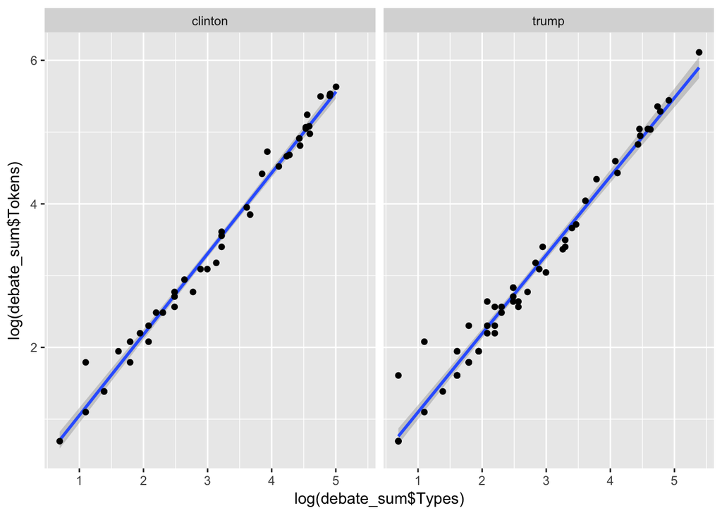

```r
ggplot(debate_sum, aes(log(debate_sum$Types), log(debate_sum$Tokens))) +
  geom_smooth(method='lm')+geom_point()+facet_wrap(~speaker)
```

4)Analyze the lexical diversity across the candidates before and after they became their parties’ respective candidates:

```r
################################################################################
# Candidate Readbility Scores
################################################################################
#Clinton readability After Nomination
clinton0_readability <- textstat_readability(clinton_1, measure="Flesch.Kincaid")
clinton0_readability<-mean(clinton0_readability)
#Clinton Readability Before Nomination
clinton1_readability <- textstat_readability(clinton_0, measure="Flesch.Kincaid")
clinton1_readability<-mean(clinton1_readability)
```

```r
#Trump Readability Before Nomination
trump0_readability <- textstat_readability(trump_0, measure="Flesch.Kincaid")
trump0_readability<-mean(trump0_readability)

#Trump Readbility After Nomination
#trump0_readability <- textstat_readability(trump_1, measure="Flesch.Kincaid")
#mean(trump0_readability)
```

Readability Scores for Candidates Before and After Primary

```r
test<-1


candidates = c("Clinton Before Nomination","Clinton After Nomination", "Trump Before Nomination","Trump After Nomination")
scores = c(clinton0_readability, clinton1_readability, trump0_readability, test)
readability<-data.frame(candidates, scores)
pander(readability)
```

[output not shown]

Note: The lexical diversity for Trump after the nomination was throwin an ‘Inf’ result, not sure what is causing that result.

Lexical Diversity Scores for Candidates Before and After Primaries

```r
################################################################################
# Candidate Lexile Diversity Scores:
################################################################################
#Lexical Diversity: Trump before nomination
trump0_dfm<-dfm(trump_0)
lexdiv_trump0<-textstat_lexdiv(trump0_dfm, measure="TTR")
lexdiv_trump0<-mean(lexdiv_trump0)

#Lexical Diversity: Trump after nomination
trump1_dfm<-dfm(trump_1)
lexdiv_trump1<-textstat_lexdiv(trump1_dfm, measure="TTR")
lexdiv_trump1<-mean(lexdiv_trump1)
#Lexical Diversity: Clinton before nomination
clinton0_dfm<-dfm(clinton_0)
lexdiv_clinton0<-textstat_lexdiv(clinton0_dfm, measure="TTR")
lexdiv_clinton0<-mean(lexdiv_clinton0)
#Lexical Diversity: Clinton after nomination
clinton1_dfm<-dfm(clinton_1)
lexdiv_clinton1<-textstat_lexdiv(clinton1_dfm, measure="TTR")
lexdiv_clinton1<-mean(lexdiv_clinton1)

candidates_lexdiv = c("Clinton Before Nomination","Clinton After Nomination", "Trump Before Nomination","Trump After Nomination")

scores_lexdiv = c(lexdiv_clinton0, lexdiv_clinton1, lexdiv_trump0, lexdiv_trump1)

lexdiv_table <-pander(data.frame(candidates_lexdiv, scores_lexdiv))
lexdiv_table
```

| candidates_lexdiv | scores_lexdiv |
| --- | --- |
| Clinton Before Nomination | 148.7 |
| Clinton After Nomination | 292.3 |
| Trump Before Nomination | 189.6 |
| Trump After Nomination | Inf |

5. Do you have a hypothesis why patterns may be more or less pronounced between trump versus clinton? How could you test this?

The lexical diversity that exists before and after the primaries could be explained by the fact that during the primary debates there were more individuals debating than in the presidential debates. having more people debating meant less time speaking, resulting in shorter responses/fragments for each candidate. Given Heap’s Law the shorter the fragment the lower the lexical diversity. Trump’s lexical diversity may have the most signficant change simply because there were more people at the Republican debates as opposed to the Democratic debates which were only three people. Once it was the presidential debates, both candidates had more time to speak since they shared the time and stage with one other person, which resulted in longer fragments, and which according to Heap’s Law lead to more lexical diversity.

6. Remove Stopwords from Corpus

```r
################################################################################
#6) Remove stopwords from corpus
################################################################################
DEBATES_nostop <- dfm(DEBATES, remove=stopwords("english"))

Debates_clinton_nostop <- dfm(clinton, remove = stopwords("english"))

Debates_trump_nostop <- dfm(trump, remove = stopwords("english"))
```

7. Using the tokenize function, construct seperate bi-grams for the Hilary Clinton/Donald Trump parts of the corpus. Tabulte the ten most frequent bi-grams by speaker. Are these informative? Why or why not?

These bi-grams are informative as the are insights into themese in the debates as well as between candidates. The frequency of the bigrams shows the Clinton frequently spoke about former President Obama and Senator Bernie Sanders while Trump’s bi-grams are less informative but still telling of the candidate’s message. Trump’s bi-grams seem to include more common language than Clinton’s, this can also be explained by the readability score calculated for each candidate in the previous question. The Debates bi-gram is usefull because it reflects the campaign issues in the past election include health care and wall street. However, these n-grams do not provide context in terms of attitude or the message about each topic, it only reflects the frequency in which they appear in the corpus

Debate bi-gram

```r
#Debates bi-gram
tok <- quanteda::removeFeatures(quanteda::tokenize(DEBATES, remove_punct=TRUE), stopwords("english"))
tok <-unlist(tokens_ngrams(tok,n=2, concatenator=" "))
df<- data.table("token"=tok, "president"=names(tok))
df<- df[,.N, by=token][order(N, decreasing = TRUE)]
df$N<-as.numeric(df$N)
pander(df[1:10])
```

| token | N |
| --- | --- |
| United States | 83 |
| Senator Sanders | 83 |
| President Obama | 67 |
| right now | 66 |
| health care | 50 |
| New York | 46 |
| make sure | 46 |
| Wall Street | 42 |
| Well first | 39 |
| will tell | 37 |

Trump Bi-grams

```r
#trump bi-gram
tok_trump <- quanteda::removeFeatures(quanteda::tokenize(trump, remove_punct=TRUE), stopwords("english"))
tok_trump <-unlist(tokens_ngrams(tok_trump,n=2, concatenator=" "))
df1<- data.table("token"=tok_trump, "president"=names(tok_trump))
df1<- df1[,.N, by=token][order(N, decreasing = TRUE)]
df1$N<-as.numeric(df1$N)
pander(df1[1:10])
```

| token | N |
| --- | --- |
| right now | 48 |
| United States | 37 |
| will tell | 33 |
| take care | 25 |
| many people | 24 |
| just tell | 23 |
| Hillary Clinton | 20 |
| let just | 19 |
| many many | 19 |
| Middle East | 19 |

Clinton bi-gram

```r
#Clinton bi-gram
tok_clinton <- quanteda::removeFeatures(quanteda::tokenize(corpus_subset(DEBATES, speaker == 'clinton'), remove_punct=TRUE), stopwords("english"))
tok_clinton <-unlist(tokens_ngrams(tok_clinton,n=2, concatenator=" "))
df2<- data.table("token"=tok_clinton, "president"=names(tok_clinton))
df2<- df2[,.N, by=token][order(N, decreasing = TRUE)]
df2$N<-as.numeric(df2$N)
pander(df2[1:10])
```

| token | N |
| --- | --- |
| Senator Sanders | 83 |
| President Obama | 54 |
| United States | 46 |
| make sure | 44 |
| health care | 43 |
| Wall Street | 38 |
| Affordable Care | 33 |
| Care Act | 32 |
| New York | 29 |
| think important | 27 |

8. Using the collocation function in quanteda (which takes a tokenize object) construct collocations based on Chi2 test for each speaker. Order by Chi2 test statistic. What do you notice or what is strange? Can you provide a formal reasoning relating to the Chi2 test statistic formula?

In the Chi2 test for candidates, it appears that the count of the top two or three words is much greater than the next top bi-grams while the X2 statistic remains the same. The formal reasoning relating to the chi2 test statistic formula is that it describes the comparison between observered frequencies in the table with the frequences expected for independence. The large chi2 test tells us we can reject the t-test. Essenitally, the chi2 tells us that “Afforable” and “Care”, accounting for capitlization, are extremely likely to appear togethor as opposed to apart. In other words, the expected frequency of “Affordable” is marginal probabily of “Care” occuring as the first of a bigram times the marginal probablity of “care occuring as the second.”

Clinton Collocation

```r
#Clinton Chi2 Test
token_c<- tokens(corpus_subset(DEBATES, speaker=='clinton'))
clinton_collocation <- textstat_collocations(token_c, method="chi2")
pander(arrange(clinton_collocation[1:10], desc(count)) )
```

| collocation | count | X2 |
| --- | --- | --- |
| Affordable Care | 33 | 75676 |
| Supreme Court | 23 | 75676 |
| Planned Parenthood | 7 | 75676 |
| electric grid | 2 | 75676 |
| Alicia Machado | 2 | 75676 |
| Situation Room | 2 | 75676 |
| Celebrity Apprentice | 2 | 75676 |
| Stronger Together | 2 | 75676 |
| implicit bias | 2 | 75676 |
| Los Angeles | 2 | 75676 |

Trump Collocation

```r
#Trump Chi2
token_t<- tokens(corpus_subset(DEBATES, speaker=='trump'))
trump_collocation <- textstat_collocations(token_t, method="chi2")

pander(arrange(trump_collocation[1:10], desc(count)))
```

| collocation | count | X2 |
| --- | --- | --- |
| Middle East | 19 | 49978 |
| Ronald Reagan | 9 | 49978 |
| gold standard | 6 | 49978 |
| Supreme Court | 5 | 49978 |
| Palm Beach | 5 | 49978 |
| college tuition | 2 | 49978 |
| Trojan horse | 2 | 49978 |
| block grant | 2 | 49978 |
| extreme vetting | 2 | 49978 |
| Douglas MacArthur | 2 | 49978 |

9. Using the code provided in the lectures, identify collocations that are distinct to Trump vs Clinton. Based on your perception of each candidate, do the results of this analysis make sense? Provide a brief answer where  
   you summarize the most important results and your explanations.

```r
tok <- quanteda::removeFeatures(quanteda::tokenize(DEBATES, remove_punct=TRUE), stopwords("english"))
tok <-unlist(tokens_ngrams(tok,n=2, concatenator=" "))
tok<- data.table("text"=names(tok),"token"=tok)
tok[,speaker:=DEBATES[["speaker"]]]
tok<-tok[,.N,by=c("speaker","token")]
pander(tok[order(N, decreasing=TRUE)][1:20])
```

| speaker | token | N |
| --- | --- | --- |
| trump | United States | 50 |
| trump | Senator Sanders | 49 |
| trump | President Obama | 39 |
| trump | right now | 37 |
| clinton | Senator Sanders | 34 |
| clinton | United States | 33 |
| clinton | right now | 29 |
| trump | New York | 29 |
| clinton | President Obama | 28 |
| clinton | health care | 26 |
| trump | Well first | 25 |
| trump | will tell | 25 |
| trump | Wall Street | 25 |
| trump | health care | 24 |
| trump | Well think | 24 |
| clinton | make sure | 24 |
| trump | make sure | 22 |
| clinton | many people | 21 |
| trump | Social Security | 21 |
| trump | think important | 19 |

```r
clinton_join<- tok[speaker=="clinton"][,list(token, clintoncount=as.numeric(N))]
trump_join <-tok[speaker=="trump"][,list(token, trumpcount=as.numeric(N))]

wide<-merge(clinton_join, trump_join)
wide[is.na(clintoncount)]$clintoncount <-0
wide[is.na(trumpcount)]$trumpcount<-0
wide[,':='(totalcount, clintoncount+trumpcount)]
wide<-wide[order(totalcount, decreasing=TRUE)][totalcount>0]
wide[,':='(totalclinton, sum(clintoncount))]
wide[,':='(totaltrump, sum(trumpcount))]
wide[, `:=`(chi2, (totalclinton + totaltrump) * (trumpcount * (totalclinton - clintoncount) -
clintoncount * (totaltrump - trumpcount))^2/((trumpcount + clintoncount) * (trumpcount +
(totaltrump - trumpcount)) * (clintoncount + (totalclinton - clintoncount)) * ((totaltrump -
trumpcount) + (totalclinton - clintoncount))))]

pander(wide[1:20][order(chi2, decreasing=TRUE)])
```

Table continues below

| token | clintoncount | trumpcount | totalcount | totalclinton |
| --- | --- | --- | --- | --- |
| many people | 21 | 12 | 33 | 5227 |
| will tell | 12 | 25 | 37 | 5227 |
| Well think | 12 | 24 | 36 | 5227 |
| Well first | 14 | 25 | 39 | 5227 |
| New York | 17 | 29 | 46 | 5227 |
| United States | 33 | 50 | 83 | 5227 |
| Senator Sanders | 34 | 49 | 83 | 5227 |
| health care | 26 | 24 | 50 | 5227 |
| Middle East | 12 | 19 | 31 | 5227 |
| make sure | 24 | 22 | 46 | 5227 |
| Wall Street | 17 | 25 | 42 | 5227 |
| going get | 11 | 17 | 28 | 5227 |
| President Obama | 28 | 39 | 67 | 5227 |
| Care Act | 13 | 19 | 32 | 5227 |
| Affordable Care | 14 | 19 | 33 | 5227 |
| let just | 15 | 15 | 30 | 5227 |
| right now | 29 | 37 | 66 | 5227 |
| Social Security | 16 | 21 | 37 | 5227 |
| Supreme Court | 13 | 15 | 28 | 5227 |
| secretary state | 13 | 15 | 28 | 5227 |

| totaltrump | chi2 |
| --- | --- |
| 6105 | 4.084 |
| 6105 | 2.801 |
| 6105 | 2.378 |
| 6105 | 1.648 |
| 6105 | 1.563 |
| 6105 | 1.364 |
| 6105 | 0.8966 |
| 6105 | 0.6973 |
| 6105 | 0.688 |
| 6105 | 0.6798 |
| 6105 | 0.5415 |
| 6105 | 0.5285 |
| 6105 | 0.5097 |
| 6105 | 0.3908 |
| 6105 | 0.1825 |
| 6105 | 0.1817 |
| 6105 | 0.1277 |
| 6105 | 0.1241 |
| 6105 | 0.001034 |
| 6105 | 0.001034 |